# HARMONIES: A Hybrid Approach for Microbiome Networks Inference via Exploiting Sparsity

Web server development (http://lce.biohpc.swmed.edu/harmonies/) for implementing HARMONIES with both front- and back-ends.

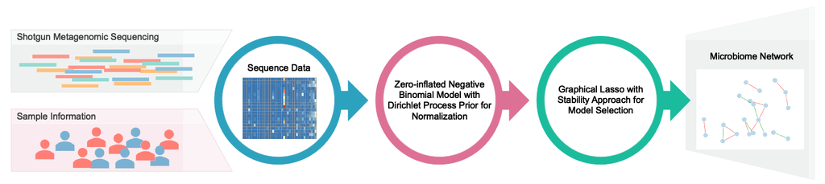

## Introduction

We introduce the online analysis tool for implementing the HARMONIES to infer the microbial association networks. We proposed the HARMONIES to

- account for the uneven sequencing depth, zero-inflation, and over-dispersion when normalizing the real microbiome data
- provide a sparse and consistent estimation of the network structure by selecting the most stable associations between taxa in the network

## Contents

- Workflow
- Online Analysis
  - Model input
  - Model output
- Download Package
- Contact
- Reference

## Workflow

Three major steps of the online analysis:

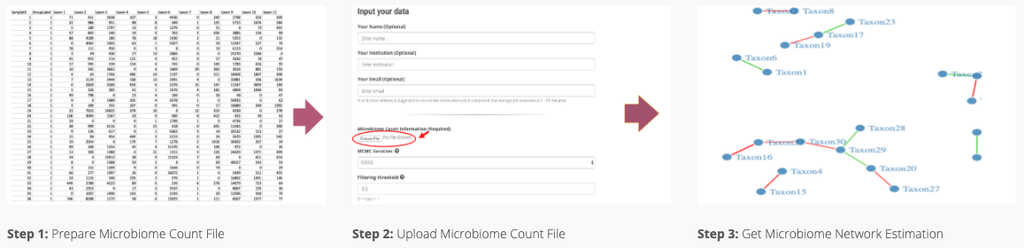

**Step 1: Prepare Microbiome Count File**

The input data is summarized into a single .csv file where

- Each row in the file corresponds to a sample (subject) in the study
- The first two columns contain the sample ID and the group information
- The 3rd to the last column consist the observed microbiome count matrix, with values being nonnegative integers

**Step 2: Upload Microbiome Count File**

Upload the .csv file at http://lce.biohpc.swmed.edu/harmonies/analysis.php and specify the model parameters. Users can provide their contact information (e.g. email address) to receive notifications since running the HARMONIES may take a while depending on the size of the input data

**Step 3: Get Microbiome Network Estimation**

The results will be available for download (as a .csv file) and other downstream analyses. Our website provide automatic visualization of network structure on the result page

## Online Analysis

Here, we explain how to use the webtool (http://lce.biohpc.swmed.edu/harmonies/analysis.php) to analyze a microbiome dataset for the purpose of network estimation.

### Model input

Users should first prepare the microbiome sequencing count data into a .csv file. An example is shown below:

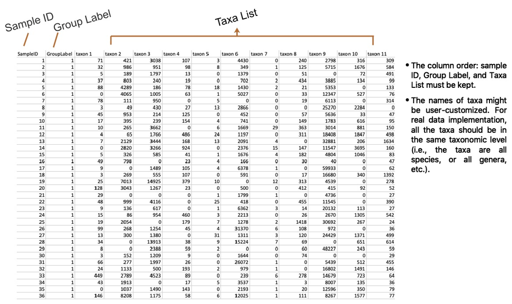

- Each row in the file corresponds to a sample (subject) in the study
- The first two columns contain the sample ID and the group information. In this example, all the samples are from the same group (e.g. patients with a same disease) and thus the group labels are all 1s. If having subjects from two groups (case and control), then the group labels should be a vector of 1 and 2
- The 3rd to the last column consist the observed microbiome count matrix, with values being nonnegative
- The column names should also be specified following the given example

Next, we provide the default settings for all the model parameters, while the users are encouraged to change the parameters based on their preferences. The meaning of each parameter is also specified (see example below).

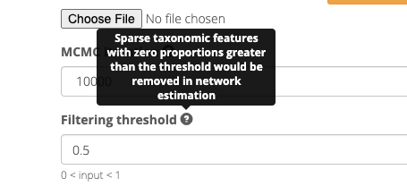

Since running the HARMONIES model may take a while, we encourage users to leave their emails when submitting the jobs. A notification email will be sent automatically once the job is finished.

### Model output

After submiting the job, users will see a waiting page similar as

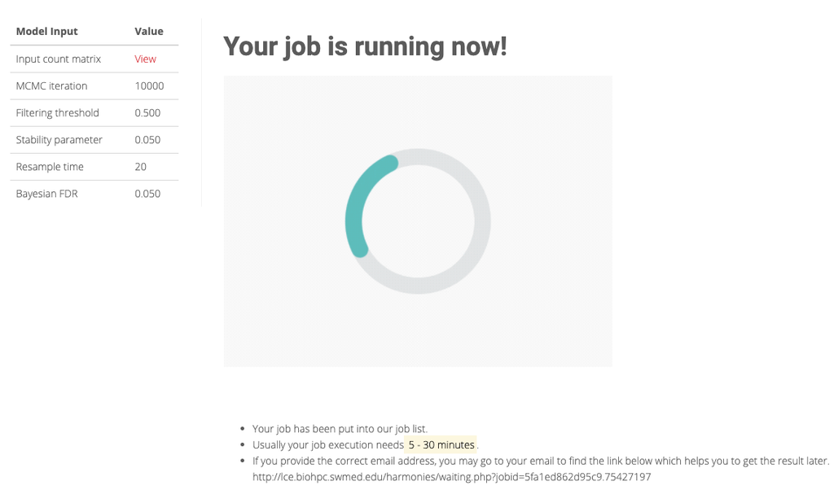

The user is able to check the input information for the submitted job on the waiting page. Then, the user will be redirected to the model fitting result page if the job is successfully finished. The result page, as shown below, provided various informations.

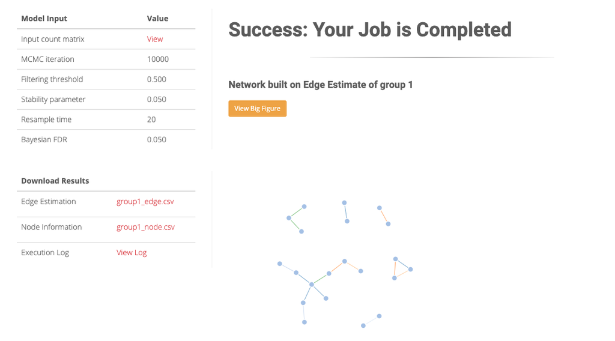

- The estimated network structure (with a green edge represents a positive partial correlation while a red edge represents a negative partial correlation)
- The model fitting results with the node and edge information for the network
- The model fitting log file

The main results are summarized into two .csv files. Below is the output from an example dataset.

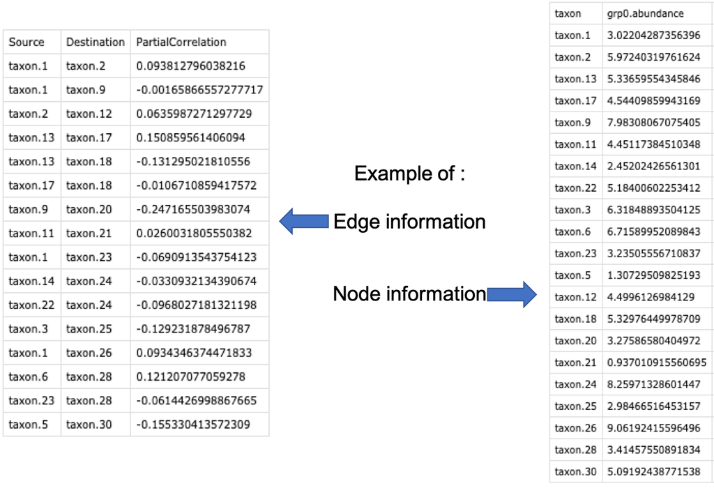

**Edge** information

- First and second columns: The names of each connected taxa pair
- Third column: Estimated partial correlation of the association between the taxa pair

**Node** information

- First column: Taxon name
- Second column: Estimated mean abundances based on the ZINB-DPP model

## Download Package

The R package is available to download at http://lce.biohpc.swmed.edu/harmonies/download.php.

The HARMONIES package serves to infer the network structure of the microbiome count data generated by next-generation sequencing (NGS) technology. It also provides functions to generate overdispersed and zero-inflated count data from a Dirichlet Multinomial model.

For more information of package installation and tutorial, please visit https://shuangj00.github.io/HARMONIES/

## Contact

Shuang Jiang shuangj@smu.edu, Department of Statistical Science, Southern Methodist University, Dallas, TX 75275

## Reference

S. Jiang et al. (2020) ``HARMONIES: A Hybrid Approach for Microbiome Networks Inference via Exploiting Sparsity", *frontiers in Genetics*, **11**:445

Link: https://doi.org/10.3389/fgene.2020.00445